# Spatial Estimation

Case Study 5

Created by Madeline Brown and Dr. Bailey Morrison

Updated 06/15/2022

University of California, Merced  
School of Engineering  
Spatial Analysis and Modeling (ENGR 180)

Assignment deliverables in RED

## Case Study Scenario

NOTE: This assignment looks much longer than others: HOWEVER! It is much more “step by step” in its instruction style. Also, it has lots of screenshots taking up space- it will go surprisingly quick =)

Congrats! You scored summer employment with the Forest Service in Oregon on the Willamette National Forest! The Forest Service seasonally employs college students every year through their Pathways Program, placing them in relevant roles. With your experience in GIS, they hired you as an Office Automation Clerk, a fancy title for GISer.

As an Office Automation Clerk, you work for the District GIS Specialist and create maps and do geospatial analyses for ALL resource groups (aka departments), such as silviculture (tree specialists), hydrology, and wildlife.

The Wildlife Resource Group has a big project coming up, and needs you to brush up on your basic spatial estimation skills.

## Introduction

Please read all of the instructions/narrative carefully! You may feel compelled to skim to find which elements you have to satisfy to get full credit. *If you skim, you may miss key sentences and you may end up doing more work than necessary!* Also, if you have questions, give the lab handout a second reading. Your question is probably answered here!  
If text is in *italics*, it’s a tool or step within ArcGIS Pro.  
If text is underlined, it’s a file.

## Instructions

You will review interpolation basics to reinforce key ideas from text and lecture. You’ll learn the order of operations for making decisions prior to interpolating data, explore plots, and create an interpolated raster from vector (point) data.

### Part 1: Data Management

A Note on Data Management  
WARNING: Raster datasets are often large! Depending on how they were they were encoded, they may also compress well. You need to extract all .zip files in order for your files to be read by ArcGIS Pro, or Excel (or most any other program).  
Be mindful of your disk space, because some of these rasters expand to hundreds of megabytes when unzipped. You will need at least 1GB of free space for this lab. Have a plan for managing your data in your labs.

### Part 2: Interpolation Basics

*2.1 Defining Interpolation and Scenarios*  
Interpolation is defined as “*predicting values for cells in a raster from a limited number of sample data points*”[1].  
You could use interpolation to create a prediction for rainfall across the State of California, using data collected in rain gauges at each UC Campus (one campus rain gauge = 1 sample data point). California’s Air Resources Control Board can monitor air quality and make assessments using air quality data collected throughout the state along highway corridors.

### Part 3. Decision Making with Interpolation

*3.1 Order of Operations*: When we interpolate data, we must work through an order of operations.

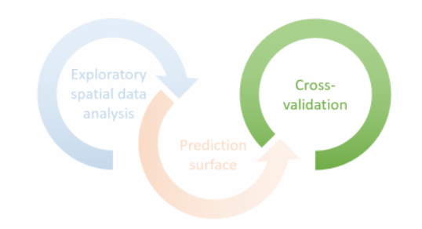

*Visual Summary courtesy of Esri*

*3.2 Key Assumptions*: Just like with statistics (that’s what interpolation is behind the scenes!), we have to explore our data ahead of time to get a better understanding of it to make analysis decisions. There are several key assumptions to verify through Exploratory Spatial Data Analysis (ESDA)  
a. Are the data representative of a *Continuous* surface? Is there a value everywhere in the surface? Think about rainfall over an area. Even if it’s NOT raining, a 0 measurement is still a value. Temperature is also helpful to think about. There isn’t ever NOT temperature.  
b. Is there *Spatial Autocorrelation*? With spatial autocorrelation, things that are closer together are more closely related (Waldo Tobler’s First Law of Geography!)  
c. Is there *Stationarity*? For any two points, their consistent distance from eachother is most important. Specific (x,y,z) location doesn’t matter. Distance explains correlation.  
d. Does the data have *Normal Distribution*? Data, if plotted in a chart, should have a nice bell-curve shape, with 95% of data falling within the first two standard deviations.  
e. Is there No *Spatial Clustering*? Data should be randomly or regularly spaced over the surface.  
f. Are there *Global Trends*? A fixed, non-random (deterministic) trend in the data explains large scale variation in your phenomenon- like how elevation may influence temperature. That relationship occurs globally.

*3.4 Cross Validate* After running your interpolation, it is critical to cross-validate your results! Were your predicted values comparable to the measured values (aka “sanity check”). We’ll do this in Part 6. You can also run other interpolation methods to see if you get similar results.

### Part 4. Plot Exploration

We are using data for this assignment that was created by Esri. They created a full, existing project and shared the project folder (like when YOU create a new project in ArcGIS Pro and it makes the folder for you). You might experience this in the workplace if a coworker gets stuck on a problem and sends you a project folder.  
*4.1 Accessing Preexisting Data*  
Navigate to your classfiles folder and explore one of your PREVIOUS labs.  
The Project folders contain the following structure.  
- ImportLog  
- Index  
- Geodatabase folder (.gdb, where your data “lives”)  
- ArcGIS Project File (your .aprx, where the visuals/map “live”)  
- ArcGIS Toolbox (if you create tools, like a ModelBuilder model, this is where it would save)  
a. To begin this project, download the data from Catcourses to your Classfiles folder. Instead of creating a new project, we are going to open the existing project’s .aprx  
b. In your downloaded InterpolIntro folder in File Explorer, DOUBLE CLICK the Project File (.aprx). It has a blue icon.  
c. Opening the .aprx will open a full project in ArcGIS Pro, with preexisting layers in the _Table of _Contents__. Because you’re opening a full project, expand the *Databases* drop down in *Catalog*, and you will see the Climate point layer.  
The OREGON data layer contains climate-related data for the state of Oregon at select weather stations.  
OPEN the attribute table and answer: What types of data are in the attribute table (based off the column headers)? How many sites are there (what is the number of assets in the table/number of rows)?  
*4.2 Verify Assumption Visually: Normal Distribution*  
To run statistical analyses and successfully (and correctly) interpolate data, we need to make sure out data is “normally distributed”

Next: Create a Histogram and Q-Q Plot Visual Interpretation  
d. In the *Contents* pane, right-click Climate, point to *Create Chart*, and then choose *Histogram*. A histogram chart window and the *Chart Properties* pane appear.  
e. Next, specify the variable that represents the measurements of the phenomenon of interest.  
f. In the *Chart Properties - Climate* pane, for *Number*, choose *Mean Aug Temp*.  
g. Next, you will visually interpret the chart to determine whether the data is normally distributed.  
h. Check the *Show Normal Distribution* box to add a normal distribution reference line to the chart.  
i. Check the *Median* box to add a line representing the median value to the chart.  
Submit a screenshot of the chart created for Mean Aug Temp with the mean, median, and normal distribution reference line. Based on a visual interpretation of the chart, are the values for Mean Aug Temp normally distributed?

You have completed the visual verification that the data appear to be normally distributed, but we need to be able to prove it with numbers as well.  
*4.3 Verify Assumption Numerically: Normal Distribution*  
Now you will review the chart statistics to determine whether the data is normally distributed.  
j. In the *Chart Properties - Climate* pane, review the mean, median, skewness, and kurtosis statistics.  
k. Histogram chart properties statistics: Based on these statistics, is the data normally distributed?  
Submit a screenshot of you statistical/numerical results. Explain in written format if the data are normally distributed based on your statistical/numerical results.  
Close your *Chart Properties* and the *Distribution Chart* created for mean august temps

### Part 5. Interpolation Methods

*5.1 Q-Q Plots*  
a. In the *Contents* pane, right-click Climate, point to *Create Chart*, and choose *QQ Plot*. A *QQ plot* chart window and the *Chart Properties* pane will appear. First, you will specify the variable that represents the measurements of the phenomenon of interest.  
b. In the *Chart Properties - Climate* pane, for *Compare The Distribution Of*, choose Mean Aug Temp.

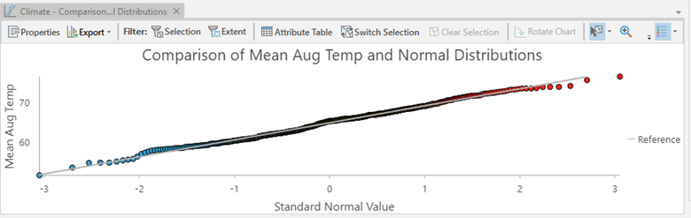

*Chart*

After you choose the comparison variable, the *QQ plot* chart is populated.  
Look at the *Chart Properties - Climate* pane.  
By default, the data is compared to a normal distribution.

**How to Choose a Method of Interpolation**

Phenomena can be measured in various ways depending on your analysis goal.

The data type of a measured phenomenon determines which geostatistical interpolation methods apply to the analysis. However, the cross-validation metrics and graphs should be evaluated to ensure that the prediction surface is valid.

2D Surfaces: x coordinate, y coordinate, value for thing being measured

3D Surfaces: x coordinate, y coordinate, z coordinate (aka elevation)  
and value for thing being measured

Polygon Surfaces: reaggregate (up or downscale) polygons to fill in missing data

Now that we know what three datatypes we can interpolate with, we can look at different types of interpolating to do for each datatype.

Is our climate data 2D, 3D, or Polygon? When we looked at the attribute table, we can see there is an Elev_Gnd_F (ground elevation in feet) and Elev_Gnd_m (ground elevation in meters).

SUBMIT A SCREENSHOT SHOWING THE SPATIAL REFERENCE FOR THIS LAYER, AND HIGHLIGHT/CIRCLE the units.

### Part 6. Interpolating Practice

Search for the *Geoprocessing* tool *Empirical Bayesian Kriging* and open it.  
a. Set your input features to Climate (your data layer)  
b. Set your Z value field to Mean Aug Temp!  
c. Wait, isn’t Z elevation?? Hover over the blue info icon and read the description. It says…” Field that holds a height or magnitude value for each point… we’re analyzing  
August Temp, not elevation, so that’s why we’re inputting Mean August Temperatures.  
d. Name your output raster IntClimT  
d. Accept all other defaults.

Click the dropdown for *Output Parameters*: See that we are creating a prediction surface? Remember that was the middle of 3 steps within the interpolation workflow.  
RUN the Tool. This may take a few minutes on the remote server.

Your results should look like…

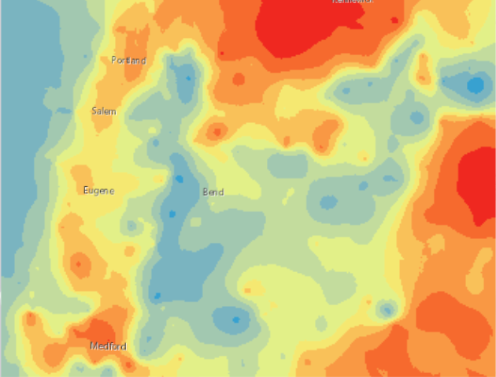

*Interpolated Output Raster*

For a “sanity check” – turn your Climate points off and on by checking and unchecking the Climate layer in the *Table of Contents*. See how the interpolated model reflects the sampled points?

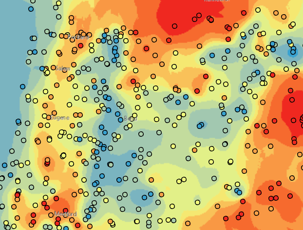

*Cross checking sampled points with output interpolated raster*

*6.2 Adding Flat File Data*  
Add the bigfoot_oregon flat file (aka .xls) from Catcourses into your *Contents* using *XY Table to Point*, and name the layer BigfootWGS84. These data are being imported NOT projected,so accept the default that populates into the Coordinate System property. This may take a few minutes to run.

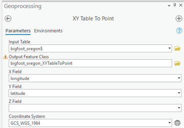

*Flat File input*

PROJECT and RENAME your Bigfoot data to BigfootPRJ to match your Climate data using the Project tool and previously gained skills. Use this dataset in the following map output.

Create a PRODUCTION quality map using your newly interpolated climate data targeting tourists who want to visit Oregon in the summer – particularly to hunt for bigfoot. Think about how your map title reflects the goal of the map. Add a TEXT BOX to your map layout with 3-4 sentences of a written description of the climate trends you interpolated.  
Save and close this project. We will use a different project for the remainder of the lab.

### Part 7. Spatial Estimation using a Species Distribution Model

Your summer project is funded by Bigfoot Field Researchers Organization (BFRO). BFRO receives funds from Big Foot enthusiasts’ donations, however the organization has recently decided to sell tourist packages for wilderness. Big Foot fanatics to bring in additional revenue to support additional Big Foot research endeavors.  
Your job as the GIS analysts is to identify where BFRO and tourists will be most likely to spot (and hopefully get a picture) of the elusive Big Foot (aka Sasquatch or Yeti) in North America by creating a Species Distribution Model (SDM)(aka Ecological Niche Model).  
SDMs assume that you can predict the entire, or potential, spatial distribution of a phenomenon, by relating the sites of known occurrence (Big Foot sightings) with predictor variables known for these sites and all other sites. A common application of this method is to predict species ranges with climate/environmental data as predictors. The following steps are usually taken:  
• Acquire locations of species occurrence and environmental data  
• The known species locations and environmental data are used to fit a model predicting likelihood of presence (or abundance) of the species  
• The model is used to predict the likelihood of presence across an area of interest (sometimes in the future or past).  
*7.1 Start Your Project*  
1. On the remote server, download the SpatialModelLab folder in CatCourses  
Assignments-> Lab 5b -> SpatialModelLab  
• Click the link to access the data, then begin download.  
• Windows will automatically download this file to Downloads.  
2. Move the zipped SpatialModelLab folder to your Classfiles folder.  
3. Unzip the SpatialModelLab folder:  
• To unzip the folder, right click on the file, click on “Extract All”, and hit enter for the extraction pop-up window.  
4. Inside the unzipped SpatialModelLab folder, open the bigfoot_distribution ArcGIS Project File (aprx).  
• All of the data you will need for this project is already loaded into this Project Folder.  
5. You should see these files mapped in the project:  
• big_foot (Shapefile)  
• mean_tave.tif (Raster)  
• total_precip.tif (Raster)  
• elevation.tif (Raster)

*7.2 Understanding your Datasets*  
A great place to start when looking to model a process, pattern, or phenomenon is to make sure you understand your data (where it came from, who made it, accuracy, format, and the fields/rows contained in the data.  
**Big Foot Sightings:**  
Your Big Foot Sightings dataset comes from The Bigfoot Field Researchers Organization and contains all Big Foot sightings since 1995 in North America. This is the same dataset you used for last week’s assignment, but for the entire continent, not just Oregon.  
Think to yourself [no written response required]:  
• Who are/What is the Bigfoot Field Researchers Organization (About BFRO)?  
• What data is included in the big_foot shapefile (look at attribute table in ArcGIS Pro)?  
• What type of shapefile is big_foot (point, polygon, line?)  
• How credible are the bigfoot sightings?  
• How accurate are the sightings?  
• Who reports the sightings?  
• How are sightings verified?  
• What type of device measures coordinates?

**Environmental Data:** You are going to use Historical Climate Data (average temperature, precipitation, and elevation) created by WorldClim (UC Davis) to model the distribution of Big Foot throughout North America.  
Think to yourself:[no written response required]  
• What is WorldClim? [https://www.worldclim.org/data/worldclim21.html]  
• What types of climate data do they offer?  
• What resolutions are available for the Historical Climate Dataset?  
• What are the dates(years) of the Historical Climate Dataset?  
• How credible is the WorldClim dataset(s)?  
•Is their dataset peer-reviewed (i.e., published in a credible journal)?  
• What type of data are the climate variables in ArcGIS (vector vs. raster)?  
Temperature, precipitation, and elevation data are generally informative variables that play a role in determining where an animal can or cannot survive (i.e. species niche), however there are many other factors/variables that may be useful for modeling species distributions as well (e.g. competition, barriers, migration, radiation, etc.). For simplicity, you will only use temperature, precipitation and elevation for this lab.

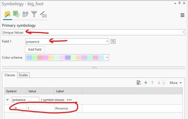

Your map should look similar to the one below (colors/shapes may vary):  
Think to yourself:[no written response required]  
• Where do most Big Foot sightings occur (Generally)?  
• Are they look clustered or spread randomly throughout North America?  
• Do you see any trends with elevation, temperature, or precipitation and the location of Big Foot sightings?  
• Do Big Foot sightings occur where the climate is warmer/cooler, high/low in elevation, and high/low precipitation?

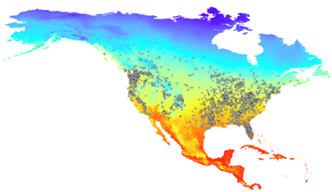

*7.4 Identify Spatial Autocorrelation*  
To Quantify whether or not Big Foot sightings are statistically clustered, random, or uniformly distributed (vs just eye-balling your map) you need to quantify the spatial autocorrelation of the points. To do this you are going to compute Moran’s I:  
1. Click on the Analysis Tab (Top of ArcGIS), then click on Tools.  
2. In the Geoprocessing Pane (Right), click on Toolboxes (under the search bar), and scroll down and click on Spatial Statistics Tools -> Analyzing Patterns -> Spatial Autocorrelation (Global Moran’s I).  
3. In the Spatial Autocorrelation tool window:  
a. Input Feature Class = big_foot  
b. Input Field = presence  
c. Check the box for “Generate Report”  
d. Leave all other boxes as is.  
e. Click on Run.

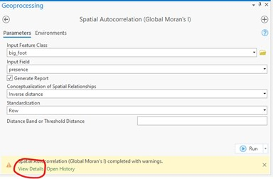

*Spatial Autocorrelation Report Settings*

4. To review the Autocorrelation report, use your computers File Explorer and navigate to your bigfoot ArcGIS project folder. In the folder you should see a file named similar to : MoransI_Result_####_#####.html. Open this file using **CHROME**(charts don’t show properly in IE)  
5. The report should look similar to this:

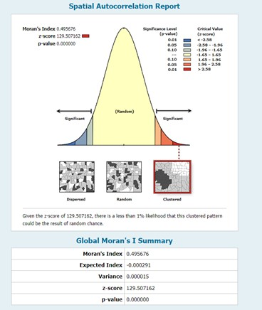

*7.5 Determine if your predictor variables are correlated*  
It is important to know if your predictor variables (temperature, precipitation, and elevation) are correlated with each other. Many models assume that predictor variables are not correlated. When variables are correlated and your model assumes independence, any results derived from the model are considered uncertain/invalid. This step helps modelers decide what type of model is appropriate for the type of data they are using so they do not invalidate model assumptions.  
1. Extract the temperature, precipitation, and elevation data for each Big Foot sighting:  
a. Click on the Analysis Tab (Top of ArcGIS), then click on Tools.  
b. In the Geoprocessing Pane (Right), click on Toolboxes (under the search bar), and scroll down and click on Spatial Analyst Tools -> Extraction -> Extract Multi Values to Points.  
c. Input Point Features = big_foot  
d. Input Rasters =  
i. Mean_tave  
ii. Total_precip  
iii. Elevation  
e. Output Field Names:  
i. Temp  
ii. Precip  
iii. Elev  
f. **Do not check the box**: Bilinear interpolation of values at point locations.  
g. Click Run

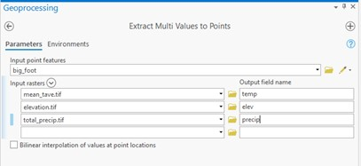

2. Make scatter plots of each predictor variable to each other:  
a. Right click on big_foot -> click on Create Charts -> scatter plot matrix  
b. In the Chart Properties Pane:  
i. Numeric Fields -> add Temp, Precip, and Elev  
ii. Check the box Show Linear Trend  
iii. Matrix Layout:  
1. Lower Left = Scatterplots  
2. Upper Right = Pearson’s r  
3. Diagonal = Field Names  
4. If you want a color scheme you can adjust this, but it is not necessary.  
3. You should now have a scatter plot matrix that looks similar to that shown below, with the Pearson’s r value (i.e. Pearson’s Correlation) reported for each pair of scatterplot Variables.  
For this assignment, any variable with a Pearson’s r > 0.75 will be considered statistically correlated.

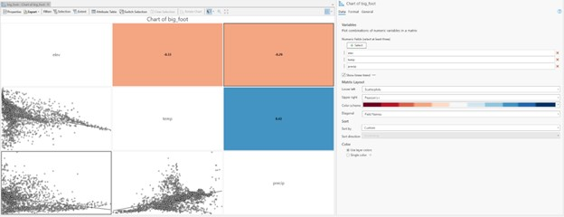

Take a screenshot of your output tables for submission.  
Think to yourself [no written response required]:  
• Are any predictor variables correlated? If so, which ones?  
• How do you know that your predictor variables are or are not correlated?  
• If the model you choose to model Big Foot distributions assumes that predictor variables are not correlated (independent of each other), will any of your predictor variables invalidate the model?

### Part 8: Creating and Training Your Bigfoot Distribution Model

1. Go to your Analysis ribbon -> Tools -> Toolboxes -> Image Analyst Tools -> Classification and Pattern Recognition -> Train Random Trees Regression Model  
   a. Input Rasters:  
   i. mean_tave.tif  
   ii. total_precip.tif  
   iii. elevation.tif  
   b. Target Raster or Points = big_foot  
   c. Target Value Field = presence  
   d. Output Regression Definition File = rf_bigfoot_model  
   e. leave any Additional Outputs empty  
   f. Run
7. After your model is done running, click on “View Details”

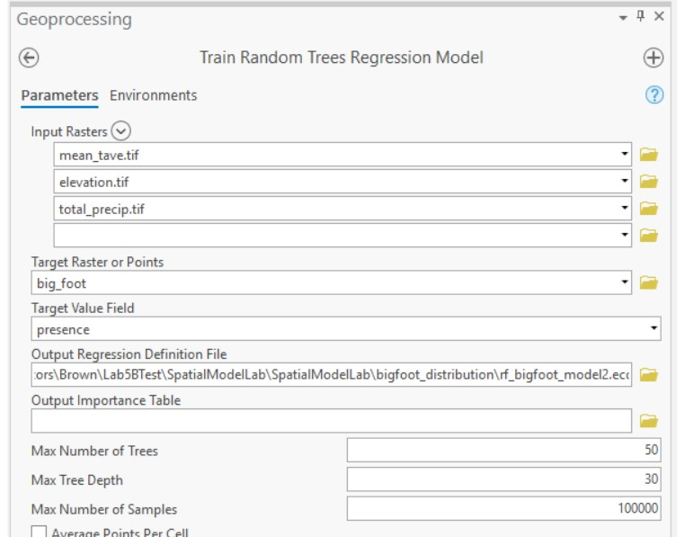

*8.2 Variable Importance Plots:*  
One important output from Random Forest models is called a Variable Importance Plot/Charts. These plots inform you of how important each individual predictor variable was for modeling the dependent variable (Big Foot Sightings), on a scale from 0 (unimportant) to 1 (very important) (i.e. how important was temperature, precipitation, and elevation were to predict Big Foot presence in North America).  
A variable with low importance essentially does nothing to help train the model, and if removed when training a model, does not alter the predictive power when all variables are used in the model. This is important for people who use “Big Data”, as they can remove uninformative data and reduce computational power and time.

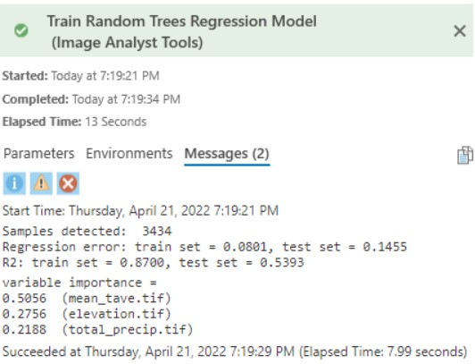

Think to yourself [no written response required]:  
• How important is each predictor variable used to model Big Foot Presence in North America?  
• What is the most important predictor variable?  
• What is the least important predictor variable?

### Part 9: Validating Your Model’s Predictive Power

After training/calibrating a model, it is standard to test/validate the results of your model before using the model to predict the dependent variable on a larger dataset. ArcGIS Pro is still developing their validation toolsets, so Dr. Bailey Morrison, a Bigfoot modelling expert, has provided you with summary statistics computed using the statistical software R.  
**Model Evaluation Numbers:**  
Statistic: Area Under Curve (AUC) = 0.88  
Statistic: Pearson’s Correlation = 0.66

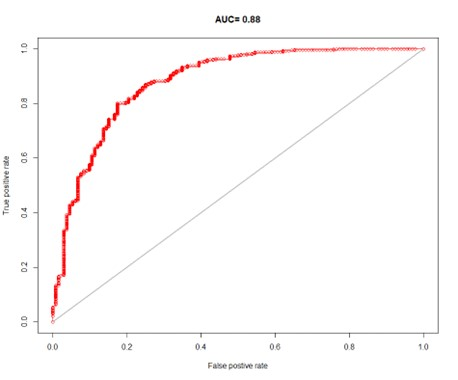

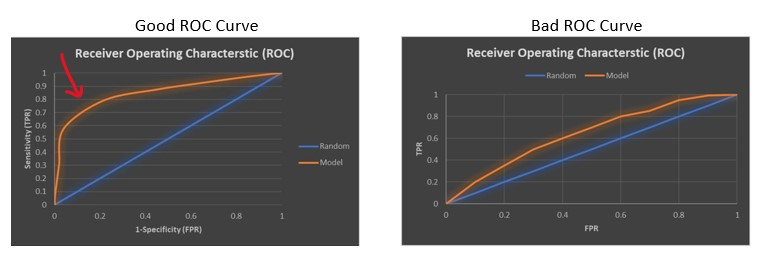

*Good and Bad ROC Curves*

### Part 10: Use Your Model to Predict Bigfoot Distributions

You have now created and trained a model that can predict the distribution of Big Foot given temperature, precipitation, and elevation (rf_bigfoot_model). Next, you will apply this model to the raster surfaces to predict the distribution of Big Foot across all of North America in a rasterized form.  
1. Analysis ribbon -> Tools -> Toolboxes -> Image Analyst Tools -> Classification and Pattern Recognition -> Predict Using Regression Model  
a. Input Raster’s:  
i. mean_tave.tif  
ii. total_precip.tif  
iii. elevation.tif  
b. Input Regression Definition File = rf_bigfoot_model.ecd  
c. Output Predictor Raster = bigfoot_dist_rf.crf  
d. Run  
This will take a few minutes.  
You should now see a new raster in your Display Pane called bigfoot_dist_rf.crf. Make sure that it is visible on the map and recolor so you can view the results.  
2. Right click on bigfoot_dist_rf.crf and click on Symbology. In the Symbology pane, choose a color scheme that show clear differences between high presence (1) and no presence (0). Click Apply and exit the symbology pane. 3. Your Big Foot distribution raster should look similar to this.

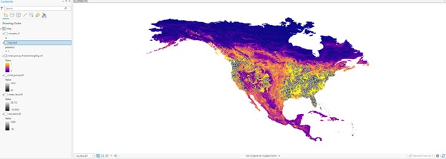

### Part 11: Interpreting Your Model Results

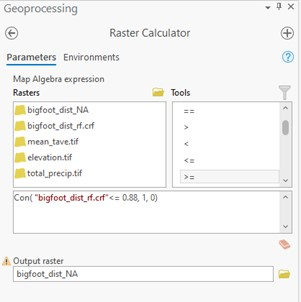

You should now have a new raster layer called bigfoot_dist_NA that only contains 1 for Present and 0 for Absent. Feel free to change the color scheme of this raster layer where you can clearly see the difference between Big Foot presence/absence.

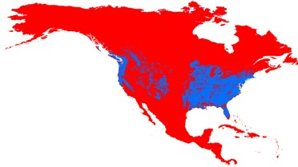

### Part 12: Production Quality Map and Write Up

Create and submit a production quality map with TWO side-by-side (or top and bottom) map frames on ONE page, showing the Probability of Bigfoot Raster you created and the Presence/Absence Raster you created . (hint: you need one Map tab PER frame in your layout).  
Answer the following [short 1-2 sentences answers are fine!]:  
a. Where would you would recommend BFRO take tourist for the best chance of spotting Big Foot?  
b. How you feel about the performance of your model- and why?  
c. Considering that Big Foot is a cryptozoological creature (unknown, legendary, or extinct animals whose present existence is disputed or unsubstantiated), do you feel the model/map you created actually presents the potential distribution of Big Foot?  
i. What do you think the reported sightings of Big Foot may be (think of another large hairy animal in forests). Check out this journal article if nothing comes to mind (https://onlinelibrary.wiley.com/doi/10.1111/j.1365-2699.2009.02152.x)  
d. Beyond inaccurate species identification of Big Foot sighting data, what other types or errors or inaccuracies may exist in the BFRO sightings dataset (not your modeled distribution)? (think about GPS, bias, hoax, etc.)?  
e. Lastly, what is your biggest takeaway from this assignment?

## Submission

At the end of this lab, you should have generated the following:  
• Part 4.1 Answer: What types of data are in the attribute table (based off the column headers)? How many sites are there (what is the number of assets in the table/number of rows)?  
• Part 4.2 Answer: Submit a screenshot of the chart created for Mean Aug Temp with the mean, median, and normal distribution reference line. Based on a visual interpretation of the chart, are the values for Mean Aug Temp normally distributed?  
• Part 4.3 Answer: Submit a screenshot of you statistical/numerical results. Explain in written format if the data are normally distributed based on your statistical/numerical results.  
• Part 5a Answer: Based on a visual interpretation of the chart, are the values for Mean Aug Temp normally distributed? Will the Mean Aug Temp values need to be transformed?  
Part 5b: Submit a screenshot showing the spatial reference for this layer and Highlight or Circle the Units  
Part 6: One production quality map using your interpolated data with added text box.  
Part 7.4: A screenshot of your Spatial Autocorrelation Report for submission.  
Part 7.5: A screenshot of your Plot Matrix  
Part 12: Production quality map with TWO frames on ONE page and accompanying responses

## References

[1]https://pro.arcgis.com/en/pro-app/2.8/tool-reference/spatial-analyst/comparing-interpolation-methods.htm